# Case Studies 2

Lecture 7 - LAS

Don van den Bergh

05-10-2026

## Today

$$\newcommand{\hypo}{\mathcal{H}}$$

Two statistical tests using two datasets:

- Z-test
- $t$-test

# The Statistical Workflow

## From a Question to a Conclusion

1. What is the *research question*?
2. What are the *population*, *sample*, *variables*, and *measurement levels*?
3. What do the *raw data* look like?
4. Which *descriptive statistics* are useful?
5. What are $\hypo_0$ and $\hypo_1$?
6. What would we expect because of *sampling variability* if $\hypo_0$ were true?
7. How far is our estimate from $\hypo_0$ in *standard errors*?
8. What is the *$p$-value*?
9. What does a *confidence interval* tell us?
10. What *can* and what *can’t* we conclude?

## The Recurring Test Statistic

For a sample mean,

$$SE_{\bar{x}} = \frac{s}{\sqrt{n}}.$$

The generic test statistic is

$$\text{test statistic}
=
\frac{\text{observed estimate} - \text{value under }\hypo_0}
{\text{standard error}}.$$

Interpretation:

*How many standard errors away from the null hypothesis is our estimate?*

# Case study 1: Can we trust an AI detector?

## Case study: Can we trust an AI detector?

Universities increasingly use AI detectors to identify work that may have been generated by tools such as ChatGPT.

- E.g., portfolio assignments.

But what does it actually mean when an AI detector flags a submission?

A 2023 *Scientific Reports* study by Ibrahim et al. tested GPTZero on real student answers and ChatGPT-generated answers across 32 university courses.

They found that GPTZero:

- incorrectly flagged *18% of human-written answers* as AI-generated;
- failed to flag *32% of genuinely AI-generated answers*.

Source: Ibrahim et al. (2023), *Scientific Reports* https://www.nature.com/articles/s41598-023-38964-3

## Detector performance

- $A$ = the submission was AI-generated.
- $H$ = the submission was human-written.
- $F$ = GPTZero flags the submission as AI-generated.

From the study,

$$P(F\mid H)=0.18 \quad \mathrm{and} \quad P(\mathrm{not}\; F\mid A)=0.32.$$

What is $P(F\mid A)$?

Since an AI-generated answer is either flagged or not flagged,
$$P(F\mid A) = 1 - P(\mathrm{not}\; F\mid A) = 1 - 0.32 = 0.68$$

## A flagged submission

Suppose GPTZero flags a student’s submission.

We are interested in

$$P(A\mid F),$$

the probability that the submission was actually AI-generated given that it was flagged.

Do we already know this probability from

$$P(F\mid A)=0.68?$$

No. $P(A\mid F)\neq P(F\mid A)$.

## What information are we missing?

Bayes’ theorem gives

$$P(A\mid F)
=
\frac{
P(F\mid A)P(A)
}{
P(F)
}.$$

We know:

$$P(F)
=
P(F\mid A)P(A)
+
P(F\mid H)P(H).$$

Therefore,

$$P(A\mid F)
=
\frac{
P(F\mid A)P(A)
}{
P(F\mid A)P(A)
+
P(F\mid H)P(H)
}.$$

## What information are we missing?

We know the detector performance.

But we do *not* yet know

$$P(A)$$

the proportion of submitted work that is actually AI-generated.

## The importance of the base rate

Let $\pi=P(A)$.

Then $P(H)=1-\pi$.

Using the reported GPTZero performance,

$$P(A\mid F)
=
\frac{
0.68\pi
}{
0.68\pi+0.18(1-\pi)
}.$$

The probability that a flagged submission is actually AI-generated depends on how common AI-generated submissions are in the first place.

## What if AI use is uncommon?

Suppose only 10% of submissions are AI-generated, i.e., $P(A)=0.10$.

Then

$$\begin{align}
P(A\mid F)
&=
\frac{
0.68(0.10)
}{
0.68(0.10)+0.18(0.90)
}\\
&= \frac{0.068}{0.230} \approx 0.296
\end{align}$$

Although GPTZero correctly flags 68% of AI-generated work, only about 30% of flagged submissions would actually be AI-generated.

## The dean’s proposal

Suppose the dean of Tilburg University argues:

We should only treat a GPTZero flag as meaningful evidence of AI use if a flagged submission has at least a 50% probability of actually being AI-generated.

Mathematically speaking, this means

$$P(A\mid F)\geq 0.50.$$

Based on the reported detector performance, what proportion of submitted work would have to be AI-generated for this statement to be true?

## Finding the critical base rate

We need to solve for $\pi$:

$$\frac{
0.68\pi
}{
0.68\pi+0.18(1-\pi)
}
=
0.50.$$

$$\begin{align}
\frac{0.68\pi}{0.68\pi+0.18(1-\pi)}
&=
0.50
&& \text{given} \\[6pt]
0.68\pi
&=
0.50\left[0.68\pi+0.18(1-\pi)\right]
&& \text{multiply by denominator} \\[6pt]
0.68\pi
&=
0.34\pi+0.09(1-\pi)
&& \text{multiply by }0.50 \\[6pt]
0.68\pi
&=
0.34\pi+0.09-0.09\pi
&& \text{expand} \\[6pt]
0.68\pi+0.09\pi-0.34\pi
&=
0.09
&& \text{collect }\pi \\[6pt]
0.43\pi
&=
0.09
&& \\[6pt]
\pi
&=
\frac{0.09}{0.43}
&& \text{divide by }0.43 \\[6pt]
\pi
&\approx
0.209.
&&
\end{align}$$

## Interpretation

At least about $20.9\%$ of all submissions would need to be AI-generated before a GPTZero flag is more likely to represent AI-generated work than human-written work.

This gives us a new question:

Is AI use among Tilburg University submissions actually above 20.9%?

We can investigate this using a sample.

## A Tilburg University study

Suppose Tilburg University randomly audits $n=200$ student submissions.

Assume the audit can reliably determine whether each submission is AI-generated.

Of the 200 submissions, 50 are AI-generated.

Therefore, the *sample proportion* is

$$\hat p
=
\frac{50}{200}
=
0.25.$$

## Is 25% enough?

The dean’s criterion requires the population proportion to exceed

$$p=0.209.$$

Our sample estimate is
$$\hat p=0.25.$$

Since

$$0.25>0.209,$$

can we conclude that more than 20.9% of all submissions are AI-generated?

## Is 25% enough?

No!

The difference could be due to *sampling variability*.

## Hypotheses

Let $p$ denote the proportion of all relevant Tilburg University submissions that are AI-generated.

We test

$$\hypo_0:p\leq0.209 \quad \mathrm{against}\quad \hypo_1:p>0.209.$$

This is a *one-sided* test.

Like last week, we perform the test at the boundary of the null hypothesis:

$$p=0.209.$$

## From proportions to means

Recall from week 2 (Bechdel example) that if we define

$$x_i=
\begin{cases}
1, & \text{if submission }i\text{ is AI-generated},\\
0, & \text{if submission }i\text{ is human-written}.
\end{cases}$$

then, the sample mean is $\bar x=\frac{1}{n}\sum_{i=1}^nx_i=\hat p.$ i.e., sample proportion of AI-generated submissions.

So testing a population *proportion* is equivalent to testing the population *mean of a binary variable*.

What does this tell us about the *sampling distribution*?

It’s normal because of the central limit theorem

There are corrected sampling distributions that incorporate that proportions are between 0 and 1.

## Sampling distribution under the null

For a binary variable with probability $p$,

$$\sigma_X
=
\sqrt{p(1-p)}.$$

Under the null hypothesis, $p_0=0.209$ and therefore,

$$\sigma_X
=
\sqrt{0.209(1-0.209)}.$$

The standard error of the sample mean is

$$SE
=
\sigma_X/\sqrt{n}
=
\sqrt{
\frac{0.209(1-0.209)}{200}
}\approx0.0287.$$

## The Z statistic

We observed $\hat p=0.25$ while $\hypo_0$ stipulates: $p_0=0.209.$

Therefore,

$$Z
=
\frac{
\hat p-p_0
}{
SE
}
=
\frac{
0.25-0.209
}{
0.0287
}
\approx1.43.$$

Using the Z-table, what is the $p$-value?

## The p-value

For $Z\approx1.43,$ we obtain $P(Z>1.43) = 0.076.$

At $\alpha=0.05,$

we *do not reject* the null hypothesis.

The observed proportion, 25%, is above the required 20.9%.

But the sample does not provide sufficiently strong evidence to conclude that the population proportion exceeds 20.9%.

## What if we had more data?

Suppose instead Tilburg University audits

$$n=1000$$

submissions.

Again, we find that $25\%$ of them are AI-generated.

So the observed proportion remains

$$\hat p=0.25.$$

What changes?

## A larger sample

The standard error is now

$$SE
=
\frac{\sigma_X}{\sqrt{n}}
=
\frac{\sqrt{p_0(1-p_0)}}{\sqrt{n}}
=
\sqrt{
\frac{0.209(1-0.209)}{1000}
}
\approx0.0129.$$

*Increasing* the sample size made the standard error *smaller*.

Therefore,

$$Z
=
\frac{
\hat p-p_0
}{
SE
}
=
\frac{
0.25-0.209
}{
0.0129
}
\approx3.18.$$

Now, $p < 0.001$, and we would reject $\hypo_0$.

## Same effect, different evidence

In both studies,

$$\hat p=0.25.$$

But:

$$\begin{align}
n=200
\qquad&\Rightarrow\qquad
Z\approx1.43\\
n=1000
\qquad&\Rightarrow\qquad
Z\approx3.18.
\end{align}$$

- The estimated proportion did not change.
- The *uncertainty about that estimate* changed.

## Recap

Our original question was

$$P(A\mid F).$$

Bayes’ theorem showed that the answer depends on

1. how well the detector works, and
2. how common AI-generated submissions are.

Using the GPTZero results,

$$P(A\mid F)
=
\frac{
0.68P(A)
}{
0.68P(A)+0.18P(H)
}.$$

## Recap

The significance test addressed a different question:

Do the data provide evidence that AI use is common enough for a GPTZero flag to be more likely correct than incorrect?

## What did we learn?

A statement like

- “GPTZero detects 68% of AI-generated submissions”

does *not* tell us

- “A submission flagged by GPTZero has a 68% probability of being AI-generated.”

To answer the second question, we also need the *base rate*.

## What did we learn?

Bayes’ theorem combines

$$P(F\mid A),
\qquad
P(F\mid H),
\qquad
P(A)$$

to determine

$$P(A\mid F).$$

If we estimate the base rate from data, we must account for *sampling uncertainty*.

Note that this is very similar to how a $p$-value tells us how probable a test statistic at least this extreme would be if $\hypo_0$ were true, but does not tell us $P(\hypo_0\mid\text{data})$!

## Finally…

The detector results also come from a particular study:

- particular student assignments;
- particular university courses;
- a particular version of ChatGPT;
- a particular version of GPTZero;
- data collected in 2023.

If I apply this to your portfolio assignments, would these probabilities necessarily be the same?

Probably not.

# Break

See you in ~10 minutes

# Case study 2: Do we know how much we use our smartphones?

## Case study: Do we know how much we use our smartphones?

How many hours did you use your smartphone yesterday?

And how many separate times did you pick it up or check it?

How accurate do you think your estimates would be?

## Self-report versus actual behaviour

Andrews et al. (2015) asked 23 participants to estimate their typical daily smartphone use.

At the same time, an app objectively recorded their smartphone behavior for two weeks.

For every participant we therefore have:

- estimated number of daily uses;
- actual number of daily uses;
- estimated daily duration;
- actual daily duration.

Source: Andrews et al. (2015), *PLoS ONE* https://doi.org/10.1371/journal.pone.0139004

## The data

Each row represents one participant.

| Estimated uses | Actual uses | Estimated hours | Actual hours |
| --- | --- | --- | --- |
| 4.0 | 43.53 | 0.42 | 0.79 |
| 52.0 | 62.64 | 3.20 | 1.60 |
| 7.0 | 49.00 | 5.58 | 2.27 |
| 35.0 | 63.07 | 2.00 | 2.30 |
| 27.5 | 21.21 | 7.00 | 2.50 |
| 20.0 | 75.00 | 2.00 | 2.87 |

## How long do we use our phones?

Let’s first consider total daily duration.

Participants estimated that they used their smartphones for, on average,

$$4.12\text{ hours per day}.$$

The objective measurements showed an average of

$$5.06\text{ hours per day}.$$

So participants underestimated their smartphone use by almost an hour.

Is that convincing evidence that people systematically underestimate their smartphone use?

## Looking at the individual participants

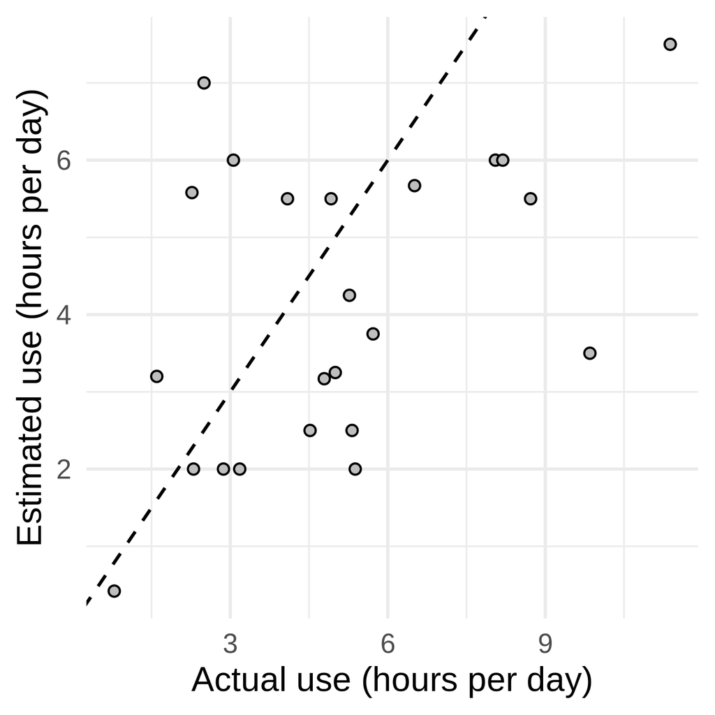

The dashed line represents a perfect agreement.

Points below the line are to participants who *underestimated* their use.

Points above the line are to participants who *overestimated* their use.

## Two measurements per participant

For each participant, we now have *two observations*:

$$\text{estimated use}
\qquad\text{and}\qquad
\text{actual use}.$$

These observations are not independent.

But we can turn them into one variable.

For participant $i$, define

$$D_i =
\text{estimated duration}_i
-
\text{actual duration}_i.$$

## The difference score

If somebody estimates their phone use perfectly, $D_i=0.$

If they underestimate their use, $D_i<0.$

If they overestimate their use, $D_i>0.$

Our original question can therefore be rewritten as:

“Is the population mean of these difference scores equal to zero?”

## The differences

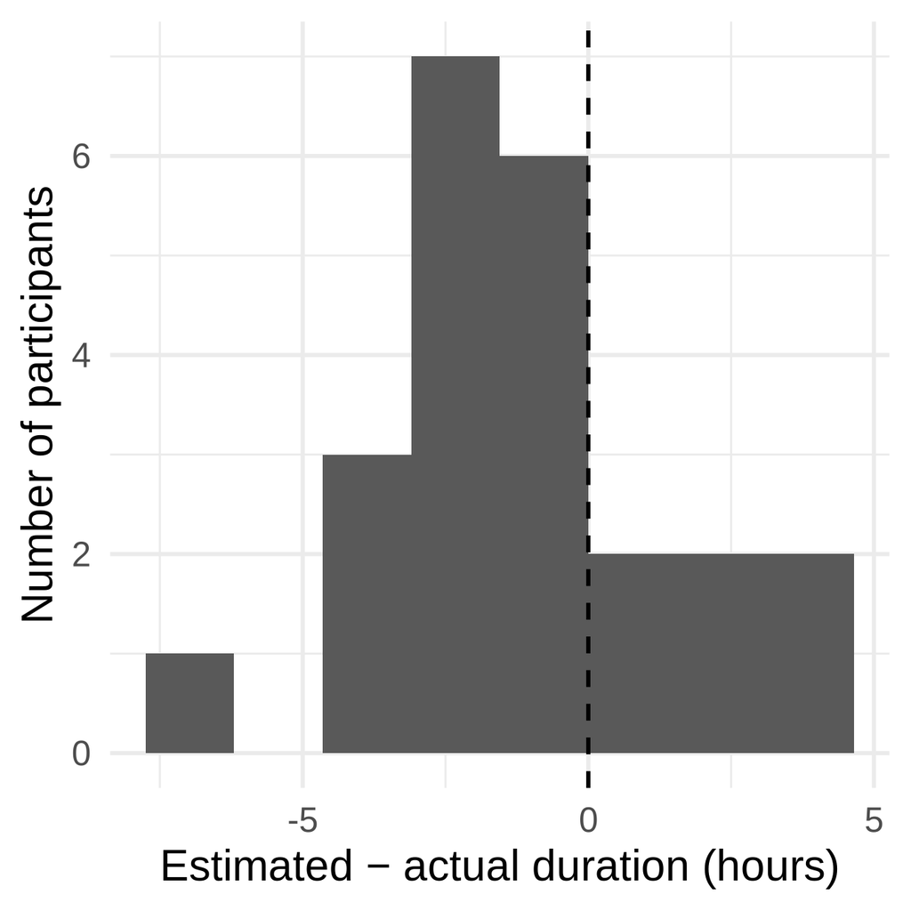

The sample mean difference is

$$\bar D
=
4.12-5.06
=
-0.93\text{ hours}.$$

## Our hypotheses

Let $\mu_D$ denote the population mean difference between estimated and actual smartphone use.

We test

$$\hypo_0:\mu_D=0
\quad
\mathrm{against}
\quad
\hypo_1:\mu_D\neq0.$$

Although every participant gave us two measurements, this is now simply a one-sample test of the difference scores.

Is this a Z or a $t$-test?

$t$-test

## The test statistic

The 23 differences have $\bar D=-0.93$ and $s_D\approx2.49.$

So,

$$SE_{\bar D}
=
\frac{s_D}{\sqrt{n}}
=
\frac{2.49}{\sqrt{23}}
\approx0.52.$$

The test statistic is

$$t
=
\frac{\bar D-0}{SE_{\bar D}}
=
\frac{-0.93}{0.52}
\approx-1.80.$$

## Is this statistically significant?

With $\alpha=0.05$, $df=22$, and $t = -1.80$ we examine the $t$-table.

We find $p(t > 1.717) = 0.05$. Since $1.717 < 1.80$ we know $p < 0.05$.

Can we reject $\hypo_0$?

No!

We have $p(t > 1.717) = 0.05$ and $p(t > 2.074) = 0.025$. Since $1.717 < 1.80 < 2.074$, we have that the actual $p$ value is between 0.05 and 0.025.

But this is a *two-sided* test, and the above are *one-tailed* $p$ values.

We need to multiply by 2.

Thus, the actual $p$ value is between 0.10 and 0.05.

## Confidence interval

The corresponding 95% confidence interval is
$$[
\bar D - t_{97.5\%,\,22} \times SE_{\bar D},\;
\bar D + t_{97.5\%,\,22} \times SE_{\bar D}
]$$

$$[-2.01,\;0.14]\text{ hours}.$$

Note that the interval contains 0.

(and yes, like last week you cannot compute this interval for a $t$-test yourself)

## What can we conclude?

Participants estimated 4.12 hours but actually used their phones for 5.06 hours.

The observed difference was almost one hour.

But, $p > 0.05$.

With only 23 participants, the data do not provide significant evidence that people under- or overestimate their total smartphone use.

## Does that mean people know their smartphone use well?

Not necessarily.

So far we have only considered *total duration*.

The researchers asked another question:

“How many separate times do you use your phone each day?”

This is a different operationalization!

## How often do we use our phones?

Participants estimated an average of about $37.20$ uses per day.

Their phones recorded an average of $84.68$ uses per day.

Actual use was more than *twice* as frequent as participants estimated.

## Looking at the individual participants

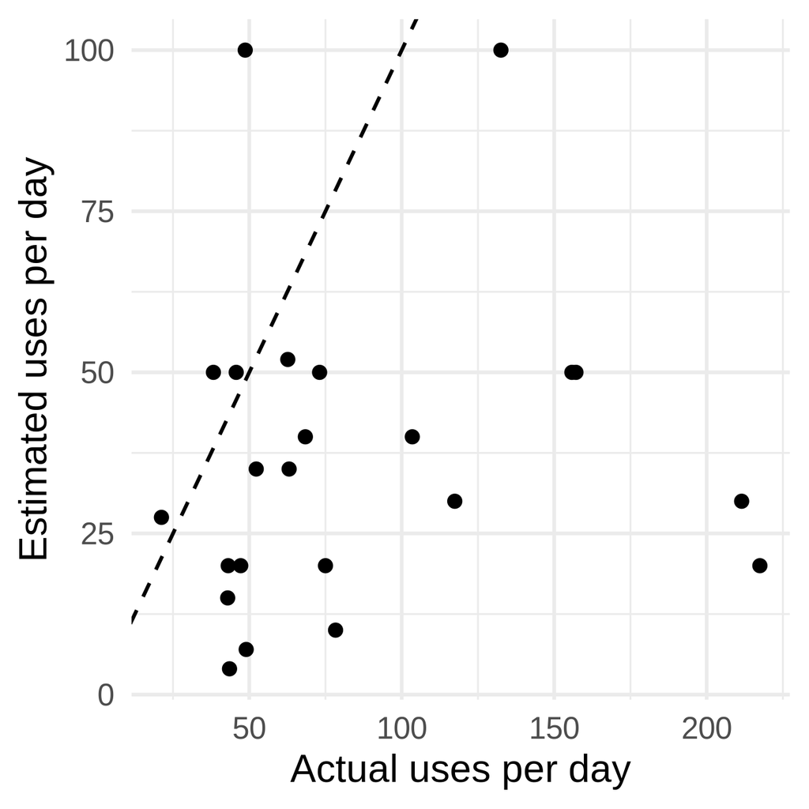

## Difference scores again

Define $D_i=\text{estimated uses}_i - \text{actual uses}_i.$

Then $\bar D = 37.20-84.68 = -47.48.$

So participants *underestimated* their smartphone use by about $47.5$ separate uses *per day*.

## The distribution of differences

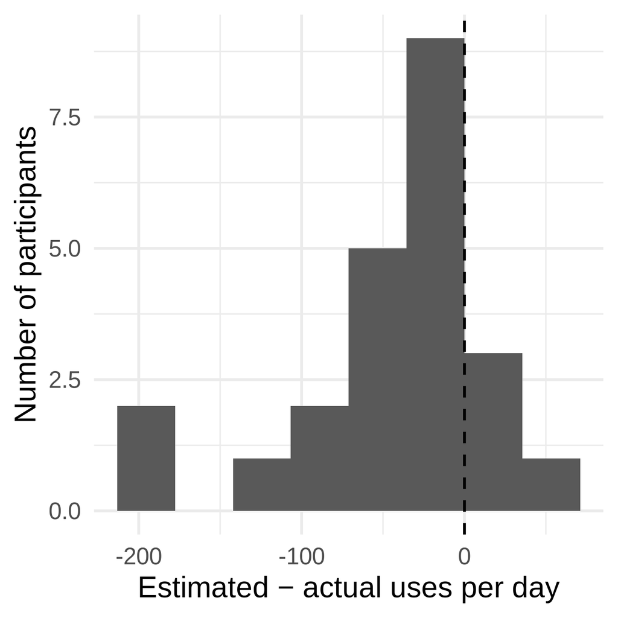

Can we explain this difference by sampling variability?

## Hypotheses

Again, let $\mu_D$ denote the population mean difference.

We test

$$\hypo_0:\mu_D=0
\quad
\mathrm{against}
\quad
\hypo_1:\mu_D\neq0.$$

The sample gives $\bar D=-47.48$ and $s_D\approx57.95$.

## The test statistic

The standard error is $SE_{\bar D} = \frac{s_D}{\sqrt{n}} = \frac{57.95}{\sqrt{23}} \approx12.09$.

The test statistic is $t = \frac{\bar D - 0}{12.09} = \frac{-47.48}{12.09} \approx-3.93.$

With $df=22$, we examine the $t$-table.

We find $p(t > 3.505) = 0.001$.

Again, this is a one-sided $p$-value, so since $3.505 < 3.93$ we can conclude that

$$p < 0.002$$

## Conclusion

We reject

$$\hypo_0:\mu_D=0.$$

The data provide strong evidence that participants systematically misestimate how often they use their smartphones.

The 95% confidence interval for the mean difference is approximately

$$[-72.55,\;-22.42].$$

## An interesting contrast

For total time:

$$\begin{aligned}
\text{Estimated} &= 4.12\text{ hours}\\
\text{Actual} &= 5.06\text{ hours}\\
p &> 0.05
\end{aligned}$$

We did not find sufficient evidence of systematic bias.

For number of uses:

$$\begin{aligned}
\text{Estimated} &= 37.20\\
\text{Actual} &= 84.68\\
p &<0.002
\end{aligned}$$

People dramatically underestimated how often they used their phones.

## What did we learn?

When the same person is measured twice, we can define a difference:

$$D_i=X_{i,1}-X_{i,2}.$$

Then a comparison between two paired measurements becomes a familiar one-sample problem:

$$\hypo_0:\mu_D=0.$$

The operationalization can determine the outcome!

## Finally…

The data were collected in 2015.

Smartphones, apps, notifications, and people’s usage patterns have changed substantially since then.

Would you expect the numerical results to be the same for students today?

Probably not.